```python
%%capture
%%shell
jupyter nbconvert --to html /content/Final_Tutorial.ipynb
```

# NOLA Court Dockets and Police Report Data Analysis: Data Science **Final Tutorial**

## This is the Data Science final project for **Ila Keshishian** and **Bennett Kahn**.

Our project website can be found at [this link](https://bennettkahn.github.io/dataScienceFinalProject/).

**Collaboration Plan**: We met in person several times to finalize our project. For all meetings, we generally coded one computer. We both discussed ideas for code and alternated betwteen who was actually typing

# Part 0: Initial Discussion

## Our main data set: 🏛 ⚖ **Orleans Parish Magistrate Court Dockets** 🏛 ⚖

We are using dockets from the Orleans Parish Sheriff’s Office. Specifically, we scraped information from the following site(s): **https://www.opso.us/dcktmstr/555555.php?&domagn=586999**

This link contains court dockets for all cases in the Magistrate Court of Orleans parish. Varying the number in **(“domagn=[num]”)** gives prior court dockets. The following important information is given about each case:

- defendant
- judge
- crime committed
- bond price
- hearing date
- zoom/in-person
- number of court appearances

Unfortunately, the race of the defendant is not included in the Docket, and there are several challenges with trying to get the race for each individual. Instead, we have run each name through software that gives the probability of an individual with a certain name being of a certain race, using the package **ethnicolr**. The documentation and source can be found at this [github site](https://github.com/appeler/ethnicolr#ethnicolr-predict-race-and-ethnicity-from-name)

From this predictive model we are able to show any disparities for the bail bond system across different races and judges/comissioners.

## An additional data set: 👮 🚔 **2021 NOPD Incident Reports** 👮 🚔

We have also implemented some analysis on the New Orleans Police Department Incident Reports from 2021. This data can be downloaded with [this link](https://data.nola.gov/api/views/6pqh-bfxa/rows.csv?accessType=DOWNLOAD)

This data includes all incident reports thus far in 2021 made by NOPD. Because we are unable to get all demographics from the court dockets scraping, we are supplementing our data analysis to include general information on race and charges in New Orleans, to give a better understanding of the New Orleans Magistrate Court. Before the final deadline of this project, we would also like to (if possible) find a way of linking incident reports in which the offender was arrested to a specific docket. This would give way to some very strong analysis.

## A statement on accuracy

Our scraping process is producing accurate data, as it is coming straight from public court records from which even the New Orleans Magistrate Court relies on. It is also complete, as the court system must have well kept records. The police records have some flaws, as the data includes every incident recorded, and therefore are missing key data points. However, we are combatting this by drilling down on the data on which a charge was documented, or an arrest was made. At this point in the incident, there is more accurate information which validates the data. Finally, we are using Ethnicolr to predict race based on last name. This process definitely introduces the most uncertainty in our data. The model is trained using Census data. An issue with this approach is that people of color are systematically underrepresented in Census Data, and using a model to predict names from a group of over policed people of color is problematic. To combat these disparities, we have set a tolerance of over 75& certainty in the names associated with Hispanic and Black races. For names associated with white race, we have set a tolerance of over 95%, as this demographic is the most represented in Census Data.

## Our hopes, dreams, and goals

**From these data sources, we hope to analyze the New Orleans Policing and Justice Department, specifically by asking:**

1. The percentage of arrests by race
2. The count for common charges by race
3. Distribution of people Arrested for a crime by race
4. What is the relationship between judge, crime, and bond. Do different judges tend to set different bond prices for same crimes?
5. Using the ethnicolr model: Is there a noticeable difference for bond price across different races when the crime is the same?
6. The number of court appearance for a certain crime

Additionally, we hope to explore how video conferencing and zoom court hearings have affected bail/bond. Although, we have not been able to extract this information yet from scraping we are excited to ask:

- What are the effects, if any, of Zoom/video conferencing court hearings on bond price (versus in person hearings)? If there is a noticeable difference in bond prices on Zoom versus in person, does it vary by judge?

```python
%%capture
!pip install ethnicolr
```

```python
%%capture
!pip install lxml
```

```python
# Importing tools used for web scraping and data analysis
import requests
from bs4 import BeautifulSoup
import pandas as pd
import numpy as np
import lxml as l
import datetime as dt
import matplotlib.pyplot as plt
import re
import time
import logging
import os
from ethnicolr import census_ln, pred_census_ln, pred_wiki_name
#from google.colab import files
logger = logging.Logger('catch_all')
```

```
2021-12-17 23:54:56.209205: W tensorflow/stream_executor/platform/default/dso_loader.cc:64] Could not load dynamic library 'libcudart.so.11.0'; dlerror: libcudart.so.11.0: cannot open shared object file: No such file or directory
2021-12-17 23:54:56.209261: I tensorflow/stream_executor/cuda/cudart_stub.cc:29] Ignore above cudart dlerror if you do not have a GPU set up on your machine.
```

# Part 1: **Data Scraping**

## Part 1a: Docket Scraping

A large component of our project is getting the actual data into an organized, tidy data frame. We are scraping court dockets, and each individual docket is stored on its own page. Complicating the process is the fact that the HTML is pretty much just text (dang messy HTML!), so, rather than using BeautifulSoup's .find() or .find_all() method to find certain data, we have to write several regular expressions to extract certain information from the entirety of the docket text. The process of scraping many thousands of dockets (talked about in part 1a-ii) is also very slow!

### Part 1a-i: Necessary functions for docket scraping

The functions in this section are helper functions for scraping each docket. They are:

1) **text_extract**

- Scrapes the entries at the bottom of a docket and returns a DataFrame with a row for each entry, where columns are 'Mag Num', 'Date', 'Judge', and 'Text'

2) **get_mag**

- Scrapes docket for magistrate number and returns it

3) **get_defendant_name**

- Scrapes docket for defendant name and returns it as string

4) **get_date_judge_chargestext**

- Scrapes docket for date, judge, charges, and text (this is the text that is passed into the text_extract function). Returns all

5) **extract_charges_bond**

- Using the charges from above, charge and bond as strings

6) **create_docket_df_entry**

- Using the return values from functions 2-5, creates a new DataFrame for one docket, one row per charge

```python
def nth_occurence(main_s, sub_s, n):
  '''Given a main string main_s and a substring sub_s, find the n_th occurence of sub_s in main_s'''

  # this code is taken from the following link: https://www.geeksforgeeks.org/python-ways-to-find-nth-occurrence-of-substring-in-a-string/

  # Finding nth occurrence of substring
  val = -1
  for i in range(0, n):
      val = main_s.find(sub_s, val + 1)

  # Printing nth occurrence
  return val
```

```python
def text_extract(s, mag_id):
  '''This extracts the text between fourth and fifth lines and creates a new entity in a second data frame with columns:
    1) mag id
    2) date
    3) text
    4) judge'''
  dates = list()
  date_starts = list()
  # regex for dates proceeding a new line; loop over all
  for match in re.finditer(r'\n(\d{2}\/\d{2}\/\d{4})\s{2,}', s):
    dates.append(match.group().strip())
    date_starts.append(match.start())

  entities = list()
  for i,d in enumerate(date_starts):
    if i != len(dates) - 1:
      entities.append(s[date_starts[i]:date_starts[i+1]])
    else:
      fifth_line = nth_occurence(s, "="*78, 2)
      entities.append(s[date_starts[i]:fifth_line])
  texts = list()
  judges = list()
  for e in entities:
    reg = re.search(r'\n\s+[A-Z]', e)

    text = e[reg.start():].strip('\n')
    texts.append(text)

    reg1 = re.search(r'\s+([A-Z]+)', e)
    judge = reg1.group(1)
    judges.append(judge)

  return pd.DataFrame({'Mag Num': mag_id, 'Date': dates, 'Judge': judges, 'Text': texts})
```

```python
def get_mag(soup):
    """WORKING REGEX TO GET MAG NUMBER"""
    mag_num = re.search(r'MAG#: (\d{6})', soup).group(1)
    return mag_num
```

```python
def get_defendant_name(text):
    """Using split with new line as delimeter -- standard spacing on top half of docket"""
    defendant = text[9].strip()
    return defendant
```

```python
def get_date_judge_chargestext(text):
    """Getting the date and judge for the proceeding and extracting the charges text"""
    # It is always two lines after the 4th equal sign line
    equalsignline = 0
    charges = []
    for (count,line) in enumerate(text):
        if line == "=" * 78:
            equalsignline +=1
        if equalsignline == 2:
            charges.append(text[count])
        elif equalsignline == 4:
            #print(mag_num, text[count+2]
            date, judge = re.sub('\*','',text[count+2]).split()
            proceedings = '\n'.join(text[count:])
            break
    return date, judge, charges, proceedings
```

```python
def extract_charges_bond(charges):
    """Takes "charges" from above and extracts count, code, bond, and charge"""
    cnt = []
    code = []
    bond = []
    charge = []
    for i, line in enumerate(charges[3:-1]):
        #print("i and line:",i,line)
        if 'BOND:' in line:
            s = line.split()
            bond_ind = s.index("BOND:")
            cnt.append(s[0])
            code.append(" ".join(s[1:bond_ind]))
            bond.append(s[bond_ind +1])
        elif defendant in line:
            pass
        else:
            s = line.split()
            charge.append(" ".join(s[:]))
    return cnt, code, bond, charge
```

```python
def create_docket_df_entry(mag_num, defendant, date, bond, judge, cnt, code, charge):
    # Duplicating the data that is the same for each charge on docket
    mag_nums = [mag_num] * len(bond)
    defendants = [defendant] * len(bond)
    dates = [date] *len(bond)
    judges = [judge] * len(bond)
    #Create a dataframe using the extracted data
    docket = pd.DataFrame({"Mag Num": mag_nums,"Defendant": defendants, "Judge": judges, "Count": cnt, "Code": code,"Charge": charge, "Bond": bond, "Date": dates})
    return docket
```

### Part 1a-ii: Scraping, organizing, cleaning, and combining court dockets

In this section we call upon the functions in Part 1-a in order to scrape dockets in a certain range of magistrate numbers. We store the data in two different DataFrames:

1) **dockets** which stores general information about the docket (a row here corresponds to a charge for a defendant, meaning one docket often maps to multiple rows)

2) **proceedings_df** which stores the text entries in the proceedings section. The unifying key between these DataFrames is "Mag Num".

Since scraping multiple dockets is pretty slow, we organize this code so that we can invoke our **scrape_dockets()** function at any time. Each call of **srape_dockets(start, end)** creates two csv files, dockets.csv and proceedings.csv, for the DataFrames dockets and proceedings_df, respectively. Of note is the fact that we wrap each scrape attempt of one docket in a "try, except" block because there are several dockets which do not scrape properly for one reason or another (often this is because the case number is not on file).

For the analsyis that follows, we have scraped dockets with **magistrate numbers from 554,000 to 564,000**, 2000 dockets at a time. Thus, we had five of each dockets.csv and proceedings.csv, each with a numerical extension saved in our directory. We use our **combined_scraped_dfs()** function to read in all csv's of scraped dockets and combine them into two master data frames, **all_dockets** and **all_proceedings**. **combined_scraped_dfs()** is useful across many rounds of scraping and storing interim csv files because it only reads in and combines csv files in the directory that it has not already done. Also, it saves all_dockets and all_proceedings to their own master csv files and reads in and adds to *those* csv files if its not the first call of the function. **This allows us to scrape additional dockets whenever and continuously append to two master csv files (and their respective DataFrames), with no risk of duplicate entries (should the same docket be scraped more than once) or losing previously-scraped dockets.**

```python
def scrape_dockets(start_mag_num, end_mag_num):
    '''Scrape dockets in range start_mag_num to end_mag_num, exclusive'''


    '''
    NOTE TO SELF (11/16/21): prior to 554000, there was a mistake in text_extract:
      - i was doing s.index(date) to search for all date entries but sometimes
        date occurs in text of proceedings text, so this was causing nonetype issues

    What this means: may need to redo all dockets scraped prior to 554000


    NOTE TO SELF: -5 of dockets.csv and proceedings.csv are the beginning of
    the file extensions beginning after fixing above
    '''
    # The prefix of every url we are scraping from
    base_url = 'https://www.opso.us/dcktmstr/555555.php?&domagn='


    # A list corresponding to the magistrate numbers of each docket
    l = list(range(start_mag_num, end_mag_num))

    soups = []

    dockets = pd.DataFrame()
    proceedings_df = pd.DataFrame()

    for num in l:
        try:
            r = requests.get(base_url + str(num))
            root = BeautifulSoup( r.content )
            soup = str(root.find('pre'))
            soup.__repr__()
            text = soup.split("\n")

            mag_num = get_mag(soup)
            defendant = get_defendant_name(text)
            date, judge, charges, proceedings = get_date_judge_chargestext(text)
            cnt, code, bond, charge = extract_charges_bond(charges)

            dockets = dockets.append(create_docket_df_entry(mag_num, defendant, date, bond, judge, cnt, code, charge), ignore_index = True)

            proceedings_df = proceedings_df.append(text_extract(proceedings, mag_num), ignore_index=True)
            time.sleep(1)

        except Exception as e:
            logger.error('Failed to upload to ftp: '+ str(e))
            print("Docket number {} is not working".format(str(num)))

    ## Initial cleaning of dataframe
    # Removes "," from the bond value and typecasts bond to numeric


    dockets["Bond"] = dockets["Bond"].str.replace(',','')
    dockets["Bond"] = pd.to_numeric(dockets["Bond"])


    dockets.to_csv("dockets.csv")
    proceedings_df.to_csv("proceedings.csv")
```

```python
def combined_scraped_dfs():
    '''combined multiple csvs resulting from scraping into one'''

    # get list of files in
    name_files = os.listdir(os.path.join("..", "milestone2", "dockets"))


    # initialize master data frames that we will combine smaller csvs into
    if 'all_dockets.csv' in name_files:
      # if we've already run this script before, read in the master csv
      all_dockets_df = pd.read_csv("all_dockets.csv")
      all_proceedings_df = pd.read_csv("all_proceedings.csv")
    else:
      # otherwise, initialize new master data frames
      all_dockets_df = pd.DataFrame()
      all_proceedings_df = pd.DataFrame()



    # text file storing dockets that we've already added to master csvs all_dockets and all_proceedings
    file = open("already_combined.txt", "a+")
    already_scraped = file.readlines()

    tot_rows = 0
    for f in name_files:
      # only combine files which we haven't already
      if f not in already_scraped:
        if f.startswith("dockets"):
          sub_df = pd.read_csv("../milestone2/dockets/" + f)
          tot_rows += sub_df.shape[0]
          all_dockets_df = all_dockets_df.append(sub_df)
          file.write(f)

        elif f.startswith("proceedings"):
          sub_df = pd.read_csv("../capstone/dockets/" + f)
          tot_rows += sub_df.shape[0]
          all_proceedings_df = all_proceedings_df.append(sub_df)
          file.write(f)


    all_dockets_df.to_csv('all_dockets.csv')
    all_proceedings_df.to_csv('all_proceedings.csv')
```

Call scrape_dockets() if doing more scraping. Commented out for now because we already scraped what we need! 😀

```python
#dockets, proceedings_df = scrape_dockets(x, y)
```

Call combine_scraped_dfs() to create/add to the master csv files. No combining needed right now! Could easily uncomment if we needed to add some more scraped dockets to our master database.

```python
#combined_scraped_dfs()
```

## Part 1b: Police Report Scraping

Here, we read in the Police Report data and perform some initial cleaning.

```python
reports_df = pd.read_csv("./data/Electronic_Police_Report_2021.csv")
```

```python
display(reports_df.head())
reports_df.dtypes;
```

|  | Item_Number | District | Location | Disposition | Signal_Type | Signal_Description | Occurred_Date_Time | Charge_Code | Charge_Description | Offender_Number | ... | Offender_Gender | Offender_Age | Victim_Number | PersonType | Victim_Race | Victim_Gender | Victim_Age | Victim_Fatal_Status | Hate Crime | Report Type |
| --- | --- | --- | --- | --- | --- | --- | --- | --- | --- | --- | --- | --- | --- | --- | --- | --- | --- | --- | --- | --- | --- |
| 0 | A-08310-21 | 5 | 013XX Flood St | CLOSED | 966 | DRUG LAW VIOLATION | 2021-01-07 12:45:00 | NaN | NaN | 2.0 | ... | MALE | 41.0 | NaN | NaN | NaN | NaN | NaN | Non-fatal | NaN | Incident Report |
| 1 | A-08310-21 | 5 | 013XX Flood St | CLOSED | 966 | DRUG LAW VIOLATION | 2021-01-07 12:45:00 | NaN | NaN | 1.0 | ... | MALE | 44.0 | NaN | NaN | NaN | NaN | NaN | Non-fatal | NaN | Incident Report |
| 2 | A-23689-21 | 5 | 022XX Gallier St | OPEN | 62 | SIMPLE BURGLARY | 2021-01-18 23:00:00 | 14 62 | SIMPLE BURGLARY | 1.0 | ... | NaN | NaN | 1.0 | VICTIM | BLACK | MALE | 44.0 | Non-fatal | NaN | Incident Report |
| 3 | A-23689-21 | 5 | 022XX Gallier St | OPEN | 62 | SIMPLE BURGLARY | 2021-01-18 23:00:00 | 14 62 | SIMPLE BURGLARY | 1.0 | ... | NaN | NaN | 2.0 | VICTIM | BLACK | MALE | NaN | Non-fatal | NaN | Incident Report |
| 4 | A-23689-21 | 5 | 022XX Gallier St | OPEN | 62 | SIMPLE BURGLARY | 2021-01-18 23:00:00 | NaN | NaN | 1.0 | ... | NaN | NaN | 3.0 | INTERVIEW | BLACK | MALE | 51.0 | Non-fatal | NaN | Incident Report |

5 rows × 23 columns

Change date column to datetime object with pd.to_datetime

```python
reports_df["Occurred_Date_Time"] = pd.to_datetime(reports_df["Occurred_Date_Time"], format = "%Y-%m-%d %H:%M:%S")
```

Make victim_fatal_status a binary variable

```python
reports_df["Victim_Fatal_Status"]= reports_df["Victim_Fatal_Status"].map({
    "Non-fatal": 0,
    "Fatal": 1
})
```

```python
reports_df.dtypes
```

```
Item_Number                    object
District                        int64
Location                       object
Disposition                    object
Signal_Type                    object
Signal_Description             object
Occurred_Date_Time     datetime64[ns]
Charge_Code                    object
Charge_Description             object
Offender_Number               float64
OffenderID                    float64
OffenderStatus                 object
Offender_Race                  object
Offender_Gender                object
Offender_Age                  float64
Victim_Number                 float64
PersonType                     object
Victim_Race                    object
Victim_Gender                  object
Victim_Age                    float64
Victim_Fatal_Status             int64
Hate Crime                     object
Report Type                    object
dtype: object
```

Dtypes lookin' good!

# Part 2: Some Cleaning and Data Analysis

## Part 2a: Cleaning and Data analysis of dockets

In this section, we perform some final cleaning on the dockets data, along with analysis of that data.

```python
all_dockets = pd.read_csv("./data/all_dockets.csv", )
all_proceedings = pd.read_csv("./data/all_proceedings.csv")
```

Somewhere in the process in Part 1, new junk columns were added. Drop them here

```python
all_dockets.drop(columns=["Unnamed: 0", "Unnamed: 0.1"], inplace=True)
```

```python
all_proceedings.drop(columns=["Unnamed: 0", "Unnamed: 0.1"], inplace=True)
```

As seen by examining the dtypes below, the dates are currently stored as objects. We need to convert them to datetime objects.

```python
all_dockets.dtypes
```

```
Mag Num        int64
Defendant     object
Judge         object
Count          int64
Code          object
Charge        object
Bond         float64
Date          object
dtype: object
```

```python
all_proceedings.dtypes
```

```
Mag Num     int64
Date       object
Judge      object
Text       object
dtype: object
```

```python
all_dockets['Date'] = pd.to_datetime(all_dockets['Date'], format="%m/%d/%Y")
```

```python
all_proceedings['Date'] = pd.to_datetime(all_proceedings['Date'], format="%m/%d/%Y")
```

Dtypes look good now

```python
all_dockets.dtypes
```

```
Mag Num               int64
Defendant            object
Judge                object
Count                 int64
Code                 object
Charge               object
Bond                float64
Date         datetime64[ns]
dtype: object
```

```python
all_proceedings.dtypes
```

```
Mag Num             int64
Date       datetime64[ns]
Judge              object
Text               object
dtype: object
```

```python
all_dockets.head()
```

|  | Mag Num | Defendant | Judge | Count | Code | Charge | Bond | Date |
| --- | --- | --- | --- | --- | --- | --- | --- | --- |
| 0 | 558000 | ROCHON, EARLNEISHA C | TAMBORELL | 1 | RS 14 37 A | AGG ASSAULT | 0.0 | 2016-09-07 |
| 1 | 558000 | ROCHON, EARLNEISHA C | TAMBORELL | 1 | RS 14 37.4 | AGG ASSAULT WITH A FIREARM | 5000.0 | 2016-09-07 |
| 2 | 558001 | WILLIAMS, CURTIS | TAMBORELL | 1 | RS 14 55 | AGG CRIMINAL DAMAGE TO PROPERTY | 0.0 | 2016-09-07 |
| 3 | 558001 | WILLIAMS, CURTIS | TAMBORELL | 1 | RS 14 37.4 | AGG ASSAULT WITH A FIREARM | 0.0 | 2016-09-07 |
| 4 | 558001 | WILLIAMS, CURTIS | TAMBORELL | 1 | RS 14 95.1 | POSS OF A FIREARM OR WEAPON BY FELON | 0.0 | 2016-09-07 |

```python
num_appearances = list(all_proceedings.groupby("Mag Num")["Date"].count()) + [1]
len(num_appearances)
```

```
9287
```

We want to create a third DataFrame, **defendants**, which stores information only about the defendant associated with a specific magistrate number.

```python
defendants = all_dockets[["Mag Num", "Defendant"]].copy()
```

```python
defendants.drop_duplicates(inplace=True)
```

```python
defendants.head()
```

|  | Mag Num | Defendant |
| --- | --- | --- |
| 0 | 558000 | ROCHON, EARLNEISHA C |
| 2 | 558001 | WILLIAMS, CURTIS |
| 6 | 558002 | BERGERON, CODY M |
| 7 | 558003 | TARDY, VERNON |
| 10 | 558004 | HERNANDEZ, SAMUEL |

```python
defendants["num_appearances"] = num_appearances
```

```python
defendants.shape[0]
```

```
9287
```

```python
defendants[['last_name','first_name']] = defendants["Defendant"].str.split(', ', expand=True)
```

```python
defendants.head()
```

|  | Mag Num | Defendant | num_appearances | last_name | first_name |
| --- | --- | --- | --- | --- | --- |
| 0 | 558000 | ROCHON, EARLNEISHA C | 3 | ROCHON | EARLNEISHA C |
| 2 | 558001 | WILLIAMS, CURTIS | 2 | WILLIAMS | CURTIS |
| 6 | 558002 | BERGERON, CODY M | 3 | BERGERON | CODY M |
| 7 | 558003 | TARDY, VERNON | 6 | TARDY | VERNON |
| 10 | 558004 | HERNANDEZ, SAMUEL | 2 | HERNANDEZ | SAMUEL |

We use a library called **ethnicolr** (https://github.com/appeler/ethnicolr) to predict the race of each defendant. Specifically, ethnicolr adds new columns to a DataFrame, where each column represents the probability that a person with last name x belongs to a certain race.

```python
defendants = census_ln(defendants, 'last_name')
```

```python
defendants.head()
```

|  | Mag Num | Defendant | num_appearances | last_name | first_name | pctwhite | pctblack | pctapi | pctaian | pct2prace | pcthispanic |
| --- | --- | --- | --- | --- | --- | --- | --- | --- | --- | --- | --- |
| 0 | 558000 | ROCHON, EARLNEISHA C | 3 | ROCHON | EARLNEISHA C | 72.09 | 20.30 | 0.64 | 0.68 | 2.60 | 3.70 |
| 1 | 558001 | WILLIAMS, CURTIS | 2 | WILLIAMS | CURTIS | 48.52 | 46.72 | 0.37 | 0.78 | 2.01 | 1.60 |
| 2 | 558002 | BERGERON, CODY M | 3 | BERGERON | CODY M | 94.80 | 2.07 | 0.35 | 0.43 | 1.07 | 1.29 |
| 3 | 558003 | TARDY, VERNON | 6 | TARDY | VERNON | 64.04 | 29.42 | (S) | (S) | 2.40 | 3.14 |
| 4 | 558004 | HERNANDEZ, SAMUEL | 2 | HERNANDEZ | SAMUEL | 4.55 | 0.38 | 0.65 | 0.27 | 0.35 | 93.81 |

```python
defendants.dtypes
```

```
Mag Num             int64
Defendant          object
num_appearances     int64
last_name          object
first_name         object
pctwhite           object
pctblack           object
pctapi             object
pctaian            object
pct2prace          object
pcthispanic        object
dtype: object
```

As seen above, **census_ln** creates columns with dtypes of ojects. We need to cast each column it created to a number using **pd.numeric()**

```python
defendants[[c for c in defendants.columns if c.startswith("pct")]] = defendants[[c for c in defendants.columns if c.startswith("pct")]].apply(pd.to_numeric, errors='coerce')
```

```python
defendants.dtypes
```

```
Mag Num              int64
Defendant           object
num_appearances      int64
last_name           object
first_name          object
pctwhite           float64
pctblack           float64
pctapi             float64
pctaian            float64
pct2prace          float64
pcthispanic        float64
dtype: object
```

Add new columns to defendants data frame. One for **most likely race** and one for **most likely race percent**

```python
defendants["most_likely_race"] = defendants[[c for c in defendants.columns if c.startswith("pct")]].idxmax(axis=1)
defendants["most_likely_race_pct"] = defendants[[c for c in defendants.columns if c.startswith("pct")]].max(axis=1)
```

```python
defendants.head()
```

|  | Mag Num | Defendant | num_appearances | last_name | first_name | pctwhite | pctblack | pctapi | pctaian | pct2prace | pcthispanic | most_likely_race | most_likely_race_pct |
| --- | --- | --- | --- | --- | --- | --- | --- | --- | --- | --- | --- | --- | --- |
| 0 | 558000 | ROCHON, EARLNEISHA C | 3 | ROCHON | EARLNEISHA C | 72.09 | 20.30 | 0.64 | 0.68 | 2.60 | 3.70 | pctwhite | 72.09 |
| 1 | 558001 | WILLIAMS, CURTIS | 2 | WILLIAMS | CURTIS | 48.52 | 46.72 | 0.37 | 0.78 | 2.01 | 1.60 | pctwhite | 48.52 |
| 2 | 558002 | BERGERON, CODY M | 3 | BERGERON | CODY M | 94.80 | 2.07 | 0.35 | 0.43 | 1.07 | 1.29 | pctwhite | 94.80 |
| 3 | 558003 | TARDY, VERNON | 6 | TARDY | VERNON | 64.04 | 29.42 | NaN | NaN | 2.40 | 3.14 | pctwhite | 64.04 |
| 4 | 558004 | HERNANDEZ, SAMUEL | 2 | HERNANDEZ | SAMUEL | 4.55 | 0.38 | 0.65 | 0.27 | 0.35 | 93.81 | pcthispanic | 93.81 |

```python
defendants.dtypes
```

```
Mag Num                   int64
Defendant                object
num_appearances           int64
last_name                object
first_name               object
pctwhite                float64
pctblack                float64
pctapi                  float64
pctaian                 float64
pct2prace               float64
pcthispanic             float64
most_likely_race         object
most_likely_race_pct    float64
dtype: object
```

Merge **defendants** and **all_dockets** to get a new DataFrame, **race_charge**. This allows us to associate race information with each charge entity.

```python
race_charge = defendants.merge(all_dockets, how='left', on = ["Mag Num", "Defendant"])
```

```python
race_charge.head()
```

|  | Mag Num | Defendant | num_appearances | last_name | first_name | pctwhite | pctblack | pctapi | pctaian | pct2prace | pcthispanic | most_likely_race | most_likely_race_pct | Judge | Count | Code | Charge | Bond | Date |
| --- | --- | --- | --- | --- | --- | --- | --- | --- | --- | --- | --- | --- | --- | --- | --- | --- | --- | --- | --- |
| 0 | 558000 | ROCHON, EARLNEISHA C | 3 | ROCHON | EARLNEISHA C | 72.09 | 20.30 | 0.64 | 0.68 | 2.60 | 3.7 | pctwhite | 72.09 | TAMBORELL | 1 | RS 14 37 A | AGG ASSAULT | 0.0 | 2016-09-07 |
| 1 | 558000 | ROCHON, EARLNEISHA C | 3 | ROCHON | EARLNEISHA C | 72.09 | 20.30 | 0.64 | 0.68 | 2.60 | 3.7 | pctwhite | 72.09 | TAMBORELL | 1 | RS 14 37.4 | AGG ASSAULT WITH A FIREARM | 5000.0 | 2016-09-07 |
| 2 | 558001 | WILLIAMS, CURTIS | 2 | WILLIAMS | CURTIS | 48.52 | 46.72 | 0.37 | 0.78 | 2.01 | 1.6 | pctwhite | 48.52 | TAMBORELL | 1 | RS 14 55 | AGG CRIMINAL DAMAGE TO PROPERTY | 0.0 | 2016-09-07 |
| 3 | 558001 | WILLIAMS, CURTIS | 2 | WILLIAMS | CURTIS | 48.52 | 46.72 | 0.37 | 0.78 | 2.01 | 1.6 | pctwhite | 48.52 | TAMBORELL | 1 | RS 14 37.4 | AGG ASSAULT WITH A FIREARM | 0.0 | 2016-09-07 |
| 4 | 558001 | WILLIAMS, CURTIS | 2 | WILLIAMS | CURTIS | 48.52 | 46.72 | 0.37 | 0.78 | 2.01 | 1.6 | pctwhite | 48.52 | TAMBORELL | 1 | RS 14 95.1 | POSS OF A FIREARM OR WEAPON BY FELON | 0.0 | 2016-09-07 |

Rename race values in most_likely_race column

```python
race_charge["most_likely_race"] = race_charge["most_likely_race"].map({
    "pctwhite": "WHITE",
    "pctblack": "BLACK",
    "pctapi": "NATIVE HAWAIIN OR OTHER PACIFIC ISLANDER",
    "pctaian": "ASIAN",
    "pcthispanic": "HISPANIC",
    "pct2prace": "TWO RACES"}
)
```

```python
race_charge["most_likely_race"].value_counts()
```

```
WHITE                                       21587
BLACK                                        2941
HISPANIC                                      864
NATIVE HAWAIIN OR OTHER PACIFIC ISLANDER      144
ASIAN                                          28
Name: most_likely_race, dtype: int64
```

### Part 2a-i: Bar Chart AND Box Plots for bond distributions of charge "Domestic Abuse Battery" by race

Below, we create three DataFrames, **dom_ab_b**, **dom_ab_h**, and **dom_ab_w**, which store all instances of domestic abuse battery for races black, hispanic, and white, respectively. Note that this race is **probabilistic**; we use the most likely race (as determined by the ethnicolor library) to represent race. We only include entries where the probability of a defendant belonging to their most likely race is above some certain threshold. For race=white, we choose 95%. For races=hispanic, black, we choose 75%. The difference here is because there are much more white people in the data (judging by ethnicolor) than there are blacks and hispanics. We lower the threshold for black and hispanic so that we get approximately the same number of domestic abuse battery charges for each.

```python
dom_ab = race_charge[(race_charge["most_likely_race_pct"]  >= 75) & (race_charge["Charge"] == "DOMESTIC ABUSE BATTERY")]
dom_ab_1 = race_charge[(race_charge["most_likely_race_pct"]  >= 95) & (race_charge["Charge"] == "DOMESTIC ABUSE BATTERY")]
dom_ab_b = dom_ab[dom_ab["most_likely_race"] == "BLACK"]
dom_ab_h = dom_ab[dom_ab["most_likely_race"] == "HISPANIC"]
dom_ab_w = dom_ab_1[dom_ab_1["most_likely_race"] == "WHITE"]
```

```python
new_df = pd.DataFrame(data={"Race": ["BLACK", "HISPANIC", "WHITE"], "Average Domestic Abuse Bond": [dom_ab_b["Bond"].mean(), dom_ab_h["Bond"].mean(), dom_ab_w["Bond"].mean()]})
```

```python
new_df.set_index('Race', inplace=True)
```

```python
new_df.head()
```

| Race | Average Domestic Abuse Bond |
| --- | --- |
| BLACK | 2576.271186 |
| HISPANIC | 2393.229167 |
| WHITE | 2516.666667 |

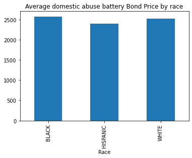

```python
new_df["Average Domestic Abuse Bond"].plot.bar(title="Average domestic abuse battery Bond Price by race")
```

The above result is surprising, as it shows a very similar average bond price for Domestic Abuse Battery accross blacks, whites, and hispanics. Our hypothesis was that minorities would have much higher bonds.

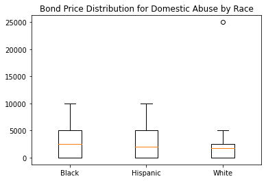

```python
fig, ax = plt.subplots()
ax.boxplot([dom_ab_b["Bond"], dom_ab_h["Bond"], dom_ab_w["Bond"]], labels=["Black", "Hispanic", "White"])
ax.set_title("Bond Price Distribution for Domestic Abuse by Race")
plt.show()
```

As our project progressed, we realized that the portion of the docket which we believed to be "Judge" did not correlate to the actual judges. We are still unsure what the names corresponded to, however we realized that in the majority of the dockets we scraped, the very first line started with "FIRST APPEARANCE HEARING IN MAGISTRATE COURT SECTION" followed by the magistrate section. Each of these magistrate sections correspond to a judge/comissioner. M1 is the one and only Magistraet judge, while M2-M5 all represent commissioners appointed by the judge. Becasue bail/bond is set at the first appearance, we assigned a new column with "Mag Section". We continued our EDA using the Mag Section as our distinguishing parameter for each judge.

```python
first_proceeding = all_proceedings.drop_duplicates(subset='Mag Num', keep='first')
first_proceeding["Mag Section"] = first_proceeding["Text"].apply(lambda x: x.split("\n")[0].strip()).map({
    "FIRST APPEARANCE HEARING IN MAGISTRATE COURT SECTION M1": "M1",
   "FIRST APPEARANCE HEARING IN MAGISTRATE COURT SECTION M3": "M3",
    "FIRST APPEARANCE HEARING IN MAGISTRATE COURT SECTION M4": "M4",
    "FIRST APPEARANCE HEARING IN MAGISTRATE COURT SECTION M2": "M2",
    "FIRST APPEARANCE HEARING IN MAGISTRATE COURT SECTION M5": "M5"
}
)
```

```python
race_charge = race_charge.merge(first_proceeding[["Mag Num","Mag Section"]], how = "left", on = "Mag Num")
```

We examine the counts of charges. We only include three of the top four charges (ones with similar average bond prices, so that the chart looks nice)

```python
race_charge["Charge"].value_counts()[:10]
```

```
DOMESTIC ABUSE BATTERY                  1262
SIMPLE BATTERY                           999
POSS OF A FIREARM OR WEAPON BY FELON     718
POSS OF DRUG PARAPHERNALIA               653
POSS MARIJUANA                           635
AGG BATTERY                              557
RESISTING AN OFFICER                     523
ILLEGAL CARRYING WEAPON WITH CDS         520
DISTURBING THE PEACE                     502
ILL POSS OF STOLEN THINGS                474
Name: Charge, dtype: int64
```

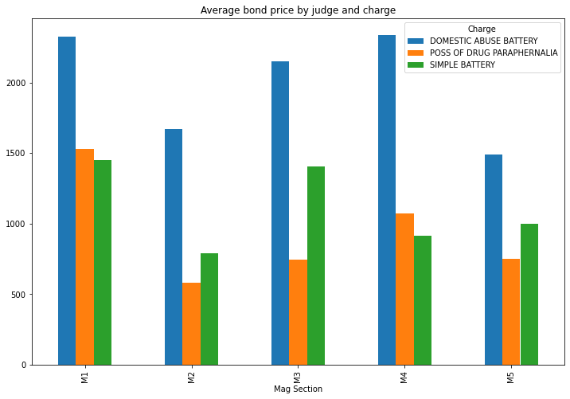

```python
wanted_charges = ["DOMESTIC ABUSE BATTERY", "SIMPLE BATTERY", "POSS OF DRUG PARAPHERNALIA"]

filtered_race_charges = race_charge[(race_charge["Charge"].isin(wanted_charges)) & (race_charge["Bond"] > 0)]

race_charge[(race_charge["Charge"].isin(wanted_charges))].pivot_table(index="Mag Section", columns=["Charge"], values="Bond", aggfunc=np.mean).plot.bar(title="Average bond price by judge and charge", figsize = (12,8))
```

The above is a bar plot of mean bond prices for 3 of the most common charges grouped by Mag Section. From this we can see that the M1 Section on average gives the highest bond prices, while M2 generally assigns the cheapest. This may be a resultant of the structure of the Magistrate Court. There is only one official judge, and they are in charge of Section 1. Sections M2-5 are headed by commissioners, which are officials appointed by the judge. While we are not sure, it is possible that the judge would be in charge of higher profile cases, which would require higher bond assignments.

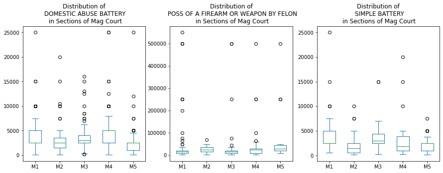

```python
#(race_charge["Charge"].isin(wanted_charges))
fig_, axs = plt.subplots(1, 3, figsize = (15,5))
wanted_charges_ = ["DOMESTIC ABUSE BATTERY", "SIMPLE BATTERY","POSS OF A FIREARM OR WEAPON BY FELON"]
for i, (charge, grp) in enumerate(race_charge[
    (race_charge["Charge"].isin(wanted_charges_))& (race_charge["Bond"] > 0)].groupby(["Charge"])):
    grp.pivot_table(index = "Mag Num", columns= "Mag Section", values = "Bond").plot.box(
        ax = axs[i], legend = True, title = f"Distribution of\n {charge}\n in Sections of Mag Court")
plt.show()
```

### Part 2a-iii: Histogram displaying freqeuncy of average number of court appearances for charges

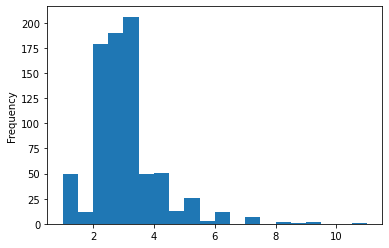

```python
charge_appear = defendants.merge(all_dockets, how = "left", on = 'Mag Num')
avg_appear = charge_appear.groupby(["Charge"])["num_appearances"].mean()
avg_appear.sort_values(ascending = False, inplace = True)
avg_appear.plot.hist(bins=20)
```

This chart shows some general trends of how many appearances a defendant will have to go into court. The x-axis is the average number of court appearances for charges and the y-axis is number of charge types; for example, the largest majority of charges have an average appearance of 2-4 court appearances. There are certain outliers, such as first degeree murder, in which defendants come in, on average, 11 times.

## Part 2b: Data analysis of 2021 Police Report data

In this section, we perfor some preliminary analysis of the 2021 police report data

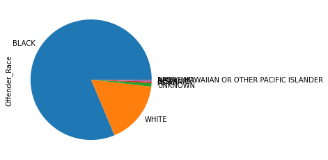

```python
reports_df[reports_df["OffenderStatus"] == 'ARRESTED']["Offender_Race"].value_counts().plot.pie()
```

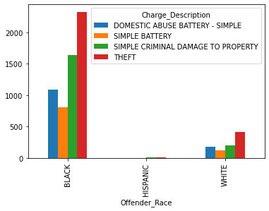

```python
charges = ["DOMESTIC ABUSE BATTERY - SIMPLE", "THEFT","SIMPLE CRIMINAL DAMAGE TO PROPERTY", "SIMPLE BATTERY", ]
races = ["BLACK", "HISPANIC", "WHITE"]
reports_df_ = reports_df[(reports_df["Offender_Race"].isin(races))
                         & (reports_df["Charge_Description"].isin(charges))]

reports_df_.pivot_table(
    index="Offender_Race", columns=["Charge_Description"],
    values="Item_Number", aggfunc='count'
).plot.bar()
```

# Part 3: Modeling

For our model, we want to predict bond given (likely) defendant race, charge, and magistrate section (aka commissioner/judge). In other words, we are creating a predictive model, where our **features** are race, charge, and mag. section, and our predicted variable is bond.

Again, we recognize the error in using ethnicolr to predict defendant race. Accordingly, we filter our race_charge DataFrame below to use only those defendants whose "most_likely_race" is above a certain threshold. For defendants who are most likely white, we set this threshold to be 90%; for all other defendants, we set this threshold to be 70%. We use a higher threshold for (likely) white defendants due to the over-representation of (likely) white people in our data set. There simply are not enough defendants who have a most_likely_race that is not white and most_likely_race_pct above 90%.

Out model is a KNearestNeighbors regression model for our predictions, with the number of neighbors set to 30. Given a new individual with feature variable values [f_0, f_1, ..., f_n], this model averages the values of the 30 points whose euclidean distance is closest to that new invididual as the individual's predicted value.

```python
# create a boolean mask for the conditions mentioned above
mask = ((race_charge["most_likely_race"] == "WHITE") & (race_charge["most_likely_race_pct"] >= 90)) | (
    (race_charge["most_likely_race"] != "WHITE") & (race_charge["most_likely_race_pct"] >= 70))
# apply that mask to the race_charge DataFrame to get a new, filtered DataFrame for our model
race_charge_filtered = race_charge[mask]
```

Below, we filter the DataFrame for our model one more time to use only the below charges. Using all 479 charges is imporactical for the model.

```python
charges_ = ["DOMESTIC ABUSE BATTERY",
"SIMPLE BATTERY",
"POSS OF DRUG PARAPHERNALIA",
"POSS MARIJUANA",
"AGG BATTERY",
"RESISTING AN OFFICER",
"ILLEGAL CARRYING WEAPON WITH CDS",
"DISTURBING THE PEACE",
"ILL POSS OF STOLEN THINGS"]

features = ["Charge", "most_likely_race", "Mag Section"]

df = race_charge_filtered[race_charge_filtered["Charge"].isin(charges_)].dropna()
X_train_dict = df[features].to_dict(orient="records")
```

Normal KNearestNeighbors model setup stuff, as seen in lecture and labs

```python
import itertools as it
from sklearn.neighbors import KNeighborsRegressor


from sklearn.feature_extraction import DictVectorizer
# Dummy encoding
vec = DictVectorizer(sparse=False)
vec.fit(X_train_dict)
X_train = vec.transform(X_train_dict)


# Standardization
from sklearn.preprocessing import StandardScaler
scaler = StandardScaler()
scaler.fit(X_train)

X_train_sc = scaler.transform(X_train)


# y train
y_train = df["Bond"]

# Step 1: Declare the model.
model = KNeighborsRegressor(n_neighbors=30)

# Step 2: Fit the model to training data.
model.fit(X_train_sc, y_train)
```

Function to output predicted bond given the features of our model. Note that we are only **setting up** the model once (above cell) and creating a function that allows us to call it as many times as we please, with whatever combination of features we desire.

```python
def predict_bond(charge, race, mag_sec):
    ''' given charge, race, and magistrate section, predict defendant's bond'''
    X_new_dict = [{
        "Charge": charge,
        "most_likely_race": race,
        "Mag Section": mag_sec,
    }]


    X_new = vec.transform(X_new_dict)

    X_new_sc = scaler.transform(X_new)
    return model.predict(X_new_sc)
```

Get two lists of all unique mag sections, and most_likely_races, respectively

```python
all_mags = list(df["Mag Section"].unique())
```

```python
all_races = list(df["most_likely_race"].unique())
```

Use itertools to compute the **cartesian product** of the sets of charges, races, and mag sections. In other words, generate all possible combinations

```python
cartesian = list(it.product(charges_, all_races, all_mags))
```

Set up a DataFrame, results_df, to store features and predicted bond

```python
results_df = pd.DataFrame(columns=["Charge", "most_likely_race", "Mag Section", "Prediction"])
```

Call our predict_bond function on all combinations of features and store predictions in result_df

```python
for t in cartesian:
    predict = predict_bond(t[0], t[1], t[2])
    results_df.loc[len(results_df.index)] = [t[0], t[1], t[2], predict[0]]
```

```python
results_df.head(40)
```

|  | Charge | most_likely_race | Mag Section | Prediction |
| --- | --- | --- | --- | --- |
| 0 | DOMESTIC ABUSE BATTERY | HISPANIC | M4 | 2269.166667 |
| 1 | DOMESTIC ABUSE BATTERY | HISPANIC | M1 | 2583.333333 |
| 2 | DOMESTIC ABUSE BATTERY | HISPANIC | M3 | 1800.833333 |
| 3 | DOMESTIC ABUSE BATTERY | HISPANIC | M5 | 2041.666667 |
| 4 | DOMESTIC ABUSE BATTERY | HISPANIC | M2 | 2108.333333 |
| 5 | DOMESTIC ABUSE BATTERY | NATIVE HAWAIIN OR OTHER PACIFIC ISLANDER | M4 | 1250.000000 |
| 6 | DOMESTIC ABUSE BATTERY | NATIVE HAWAIIN OR OTHER PACIFIC ISLANDER | M1 | 1083.333333 |
| 7 | DOMESTIC ABUSE BATTERY | NATIVE HAWAIIN OR OTHER PACIFIC ISLANDER | M3 | 872.500000 |
| 8 | DOMESTIC ABUSE BATTERY | NATIVE HAWAIIN OR OTHER PACIFIC ISLANDER | M5 | 708.333333 |
| 9 | DOMESTIC ABUSE BATTERY | NATIVE HAWAIIN OR OTHER PACIFIC ISLANDER | M2 | 958.333333 |
| 10 | DOMESTIC ABUSE BATTERY | BLACK | M4 | 2202.500000 |
| 11 | DOMESTIC ABUSE BATTERY | BLACK | M1 | 2716.666667 |
| 12 | DOMESTIC ABUSE BATTERY | BLACK | M3 | 1567.500000 |
| 13 | DOMESTIC ABUSE BATTERY | BLACK | M5 | 1725.000000 |
| 14 | DOMESTIC ABUSE BATTERY | BLACK | M2 | 2208.333333 |
| 15 | DOMESTIC ABUSE BATTERY | WHITE | M4 | 1969.166667 |
| 16 | DOMESTIC ABUSE BATTERY | WHITE | M1 | 2783.333333 |
| 17 | DOMESTIC ABUSE BATTERY | WHITE | M3 | 1667.500000 |
| 18 | DOMESTIC ABUSE BATTERY | WHITE | M5 | 1908.333333 |
| 19 | DOMESTIC ABUSE BATTERY | WHITE | M2 | 2308.333333 |
| 20 | SIMPLE BATTERY | HISPANIC | M4 | 835.833333 |
| 21 | SIMPLE BATTERY | HISPANIC | M1 | 1500.000000 |
| 22 | SIMPLE BATTERY | HISPANIC | M3 | 1118.333333 |
| 23 | SIMPLE BATTERY | HISPANIC | M5 | 641.666667 |
| 24 | SIMPLE BATTERY | HISPANIC | M2 | 616.666667 |
| 25 | SIMPLE BATTERY | NATIVE HAWAIIN OR OTHER PACIFIC ISLANDER | M4 | 683.333333 |
| 26 | SIMPLE BATTERY | NATIVE HAWAIIN OR OTHER PACIFIC ISLANDER | M1 | 1333.333333 |
| 27 | SIMPLE BATTERY | NATIVE HAWAIIN OR OTHER PACIFIC ISLANDER | M3 | 566.666667 |
| 28 | SIMPLE BATTERY | NATIVE HAWAIIN OR OTHER PACIFIC ISLANDER | M5 | 516.666667 |
| 29 | SIMPLE BATTERY | NATIVE HAWAIIN OR OTHER PACIFIC ISLANDER | M2 | 600.000000 |
| 30 | SIMPLE BATTERY | BLACK | M4 | 1108.333333 |
| 31 | SIMPLE BATTERY | BLACK | M1 | 1583.333333 |
| 32 | SIMPLE BATTERY | BLACK | M3 | 1211.666667 |
| 33 | SIMPLE BATTERY | BLACK | M5 | 966.666667 |
| 34 | SIMPLE BATTERY | BLACK | M2 | 933.333333 |
| 35 | SIMPLE BATTERY | WHITE | M4 | 1366.666667 |
| 36 | SIMPLE BATTERY | WHITE | M1 | 1500.000000 |
| 37 | SIMPLE BATTERY | WHITE | M3 | 1666.666667 |
| 38 | SIMPLE BATTERY | WHITE | M5 | 1216.666667 |
| 39 | SIMPLE BATTERY | WHITE | M2 | 1116.666667 |

Shorten name of category so it displays better on following figure

```python
results_df["most_likely_race"] = results_df["most_likely_race"].map({
    "NATIVE HAWAIIN OR OTHER PACIFIC ISLANDER": "PACIFIC ISLANDER",
    "WHITE": "WHITE",
    "BLACK": "BLACK",
    "HISPANIC": "HISPANIC"
})
```

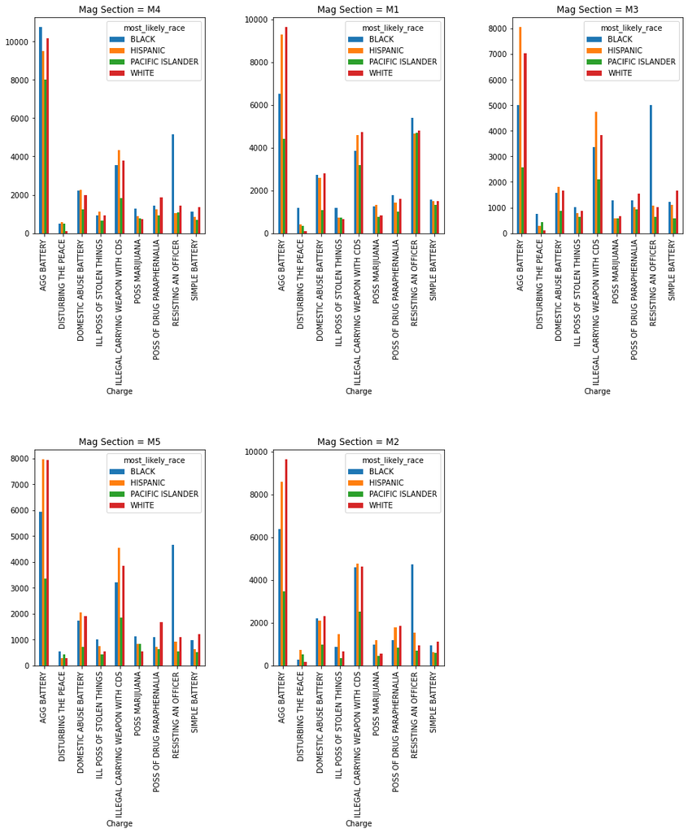

```python
fig, axs = plt.subplots(2, 3, figsize = (15,15))
plt.subplots_adjust(left=0.1,
                    bottom=0.1,
                    right=0.9,
                    top=0.9,
                    wspace=0.4,
                    hspace=1)
axs[1][2].set_visible(False)
mags = ["M1", "M2", "M3", "M4", "M5"]
m = 0
for i in range(len(axs)):
    for j in range(len(axs[i])):
        if m <= 4:
            results_df[results_df["Mag Section"] == all_mags[m]].pivot_table(index = "Charge",
                      columns = "most_likely_race",
                      values = "Prediction").plot.bar(ax=axs[i][j], title="Mag Section = {}".format(all_mags[m]))
        m += 1
#plt.show()
```

Going forward, we would like to scrape more court dockets. For this project, we have only scraped dockets from 2016, about 10,000 of them. Unfortunately, by the time we filtered our DataFrame to 1) only include defendants with a very high likely race (as predicted by ethnicolr) and 2) only include certain charges, our model had far fewer individuals than we would have liked. We believe, however, that this preliminary analysis shows differences in bond prices by magistrate section and by race, and we believe that additional dockets would show the same trend, only enforcing our findings.